# SML 201 – Week 4

John D. Storey

Spring 2016

# R Packages

# Install These Packages

Run this code in RStudio and let us know if you experience any errors.

```r
pkgs <- c("dplyr", "babynames", "readr", "tidyr", "reshape2",
          "hexbin", "ggplot2", "ggthemes", "broom",
          "devtools", "RColorBrewer", "rvest", "xtable")
install.packages(pkgs)
```

# Manipulating Data Frames

# `dplyr` Package

`dplyr` is a package with the following description:

> A fast, consistent tool for working with data frame like objects, both in memory and out of memory.

This package offers a “grammar” for manipulating data frames.

Everything that `dplyr` does can also be done using basic R commands – however, it tends to be much faster and easier to use `dplyr`.

# Grammar of `dplyr`

Verbs:

- `filter`: extract a subset of rows from a data frame based on logical conditions
- `arrange`: reorder rows of a data frame
- `rename`: rename variables in a data frame
- `select`: return a subset of the columns of a data frame, using a flexible notation

Partially based on *R Programming for Data Science*

# Grammar of `dplyr`

Verbs (continued):

- `mutate`: add new variables/columns or transform existing variables
- `distinct`: returns only the unique values in a table
- `summarize`: generate summary statistics of different variables in the data frame, possibly within strata
- `group_by`: breaks down a dataset into specified groups of rows

Partially based on *R Programming for Data Science*

# Example: Baby Names

```r
> library("dplyr", verbose=FALSE)
> library("babynames")
> ls()
character(0)
> babynames <- babynames::babynames
> ls()
[1] "babynames"
```

# `babynames` Object

```r
> class(babynames)
[1] "tbl_df"     "tbl"        "data.frame"
> dim(babynames)
[1] 1825433       5
```

```r
> babynames
Source: local data frame [1,825,433 x 5]

    year   sex      name     n       prop
   (dbl) (chr)     (chr) (int)      (dbl)
1   1880     F      Mary  7065 0.07238359
2   1880     F      Anna  2604 0.02667896
3   1880     F      Emma  2003 0.02052149
4   1880     F Elizabeth  1939 0.01986579
5   1880     F    Minnie  1746 0.01788843
6   1880     F  Margaret  1578 0.01616720
7   1880     F       Ida  1472 0.01508119
8   1880     F     Alice  1414 0.01448696
9   1880     F    Bertha  1320 0.01352390
10  1880     F     Sarah  1288 0.01319605
..   ...   ...       ...   ...        ...
```

# Peek at the Data

```r
> set.seed(201)
> sample_n(babynames, 10)
Source: local data frame [10 x 5]

    year   sex    name     n         prop
   (dbl) (chr)   (chr) (int)        (dbl)
1   1991     M  Esaias     5 2.359700e-06
2   1933     F   Maida    33 3.155410e-05
3   1967     M   Alvis    33 1.853916e-05
4   1905     M Gaylord    11 7.679151e-05
5   1993     F Kyleigh   157 7.965969e-05
6   1927     M   Della     8 6.886519e-06
7   1908     F Luberta    12 3.384753e-05
8   1968     F  Andrea  7086 4.145300e-03
9   1921     F Ardelle    50 3.907288e-05
10  1955     M  Dainel     7 3.351657e-06
> # try also sample_frac(babynames, 6e-6)
```

# `%>%` Operator

Originally from R package `magrittr`. Provides a mechanism for chaining commands with a forward-pipe operator, `%>%`.

```r
> x <- 1:10
>
> x %>% log(base=10) %>% sum
[1] 6.559763
>
> sum(log(x,base=10))
[1] 6.559763
```

```r
> babynames %>% sample_n(5)
Source: local data frame [5 x 5]

   year   sex    name     n         prop
  (dbl) (chr)   (chr) (int)        (dbl)
1  1979     M   Sunil    42 2.344364e-05
2  1996     F  Kelina     5 2.608857e-06
3  1991     F  Gimena     7 3.443326e-06
4  1979     M Neilson     9 5.023636e-06
5  1984     F Romelia     5 2.774045e-06
```

# `filter()`

```r
> filter(babynames, year==1880, sex=="F")
Source: local data frame [942 x 5]

    year   sex      name     n       prop
   (dbl) (chr)     (chr) (int)      (dbl)
1   1880     F      Mary  7065 0.07238359
2   1880     F      Anna  2604 0.02667896
3   1880     F      Emma  2003 0.02052149
4   1880     F Elizabeth  1939 0.01986579
5   1880     F    Minnie  1746 0.01788843
6   1880     F  Margaret  1578 0.01616720
7   1880     F       Ida  1472 0.01508119
8   1880     F     Alice  1414 0.01448696
9   1880     F    Bertha  1320 0.01352390
10  1880     F     Sarah  1288 0.01319605
..   ...   ...       ...   ...        ...
> # same as filter(babynames, year==1880 & sex=="F")
```

```r
> filter(babynames, year==1880, sex=="F", n > 5000)
Source: local data frame [1 x 5]

   year   sex  name     n       prop
  (dbl) (chr) (chr) (int)      (dbl)
1  1880     F  Mary  7065 0.07238359
```

# `arrange()`

```r
> arrange(babynames, name, year, sex)
Source: local data frame [1,825,433 x 5]

    year   sex  name     n         prop
   (dbl) (chr) (chr) (int)        (dbl)
1   2007     M Aaban     5 2.260251e-06
2   2009     M Aaban     6 2.834029e-06
3   2010     M Aaban     9 4.390297e-06
4   2011     M Aaban    11 5.429927e-06
5   2012     M Aaban    11 5.440091e-06
6   2013     M Aaban    14 6.961721e-06
7   2014     M Aaban    16 7.882569e-06
8   2011     F Aabha     7 3.622491e-06
9   2012     F Aabha     5 2.587144e-06
10  2014     F Aabha     9 4.642684e-06
..   ...   ...   ...   ...          ...
```

# `arrange()`

```r
> arrange(babynames, desc(name), desc(year), sex)
Source: local data frame [1,825,433 x 5]

    year   sex      name     n         prop
   (dbl) (chr)     (chr) (int)        (dbl)
1   2010     M     Zzyzx     5 2.439054e-06
2   2014     M     Zyyon     6 2.955964e-06
3   2010     F   Zyyanna     6 3.067323e-06
4   2009     M    Zyvion     5 2.361691e-06
5   2010     M Zytavious     6 2.926865e-06
6   2009     M Zytavious     7 3.306368e-06
7   2007     M Zytavious     6 2.712301e-06
8   2006     M Zytavious     7 3.196664e-06
9   2005     M Zytavious     5 2.352830e-06
10  2004     M Zytavious     6 2.841628e-06
..   ...   ...       ...   ...          ...
```

# `rename()`

```r
> rename(babynames, number=n)
Source: local data frame [1,825,433 x 5]

    year   sex      name number       prop
   (dbl) (chr)     (chr)  (int)      (dbl)
1   1880     F      Mary   7065 0.07238359
2   1880     F      Anna   2604 0.02667896
3   1880     F      Emma   2003 0.02052149
4   1880     F Elizabeth   1939 0.01986579
5   1880     F    Minnie   1746 0.01788843
6   1880     F  Margaret   1578 0.01616720
7   1880     F       Ida   1472 0.01508119
8   1880     F     Alice   1414 0.01448696
9   1880     F    Bertha   1320 0.01352390
10  1880     F     Sarah   1288 0.01319605
..   ...   ...       ...    ...        ...
```

# `select()`

```r
> select(babynames, sex, name, n)
Source: local data frame [1,825,433 x 3]

     sex      name     n
   (chr)     (chr) (int)
1      F      Mary  7065
2      F      Anna  2604
3      F      Emma  2003
4      F Elizabeth  1939
5      F    Minnie  1746
6      F  Margaret  1578
7      F       Ida  1472
8      F     Alice  1414
9      F    Bertha  1320
10     F     Sarah  1288
..   ...       ...   ...
> # same as select(babynames, sex:n)
```

# Renaming with `select()`

```r
> select(babynames, sex, name, number=n)
Source: local data frame [1,825,433 x 3]

     sex      name number
   (chr)     (chr)  (int)
1      F      Mary   7065
2      F      Anna   2604
3      F      Emma   2003
4      F Elizabeth   1939
5      F    Minnie   1746
6      F  Margaret   1578
7      F       Ida   1472
8      F     Alice   1414
9      F    Bertha   1320
10     F     Sarah   1288
..   ...       ...    ...
```

# `mutate()`

```r
> mutate(babynames, total_by_year=round(n/prop))
Source: local data frame [1,825,433 x 6]

    year   sex      name     n       prop total_by_year
   (dbl) (chr)     (chr) (int)      (dbl)         (dbl)
1   1880     F      Mary  7065 0.07238359         97605
2   1880     F      Anna  2604 0.02667896         97605
3   1880     F      Emma  2003 0.02052149         97605
4   1880     F Elizabeth  1939 0.01986579         97605
5   1880     F    Minnie  1746 0.01788843         97605
6   1880     F  Margaret  1578 0.01616720         97605
7   1880     F       Ida  1472 0.01508119         97605
8   1880     F     Alice  1414 0.01448696         97605
9   1880     F    Bertha  1320 0.01352390         97605
10  1880     F     Sarah  1288 0.01319605         97605
..   ...   ...       ...   ...        ...           ...
> # see also transmutate
```

# No. Individuals by Year and Sex

Let’s put a few things together now adding the function `distinct()`…

```r
> babynames %>% mutate(total_by_year=round(n/prop)) %>%
+   select(sex, year, total_by_year) %>% distinct()
Source: local data frame [270 x 3]

     sex  year total_by_year
   (chr) (dbl)         (dbl)
1      F  1880         97605
2      M  1880        118400
3      F  1881         98856
4      M  1881        108284
5      F  1882        115698
6      M  1882        122033
7      F  1883        120064
8      M  1883        112480
9      F  1884        137588
10     M  1884        122741
..   ...   ...           ...
```

# `summarize()`

```r
> summarize(babynames, mean_n = mean(n), median_n = median(n),
+           number_sex = n_distinct(sex),
+           distinct_names = n_distinct(name))
Source: local data frame [1 x 4]

    mean_n median_n number_sex distinct_names
     (dbl)    (int)      (int)          (int)
1 184.6879       12          2          93889
```

# `group_by()`

```r
> babynames %>% group_by(year, sex)
Source: local data frame [1,825,433 x 5]
Groups: year, sex [270]

    year   sex      name     n       prop
   (dbl) (chr)     (chr) (int)      (dbl)
1   1880     F      Mary  7065 0.07238359
2   1880     F      Anna  2604 0.02667896
3   1880     F      Emma  2003 0.02052149
4   1880     F Elizabeth  1939 0.01986579
5   1880     F    Minnie  1746 0.01788843
6   1880     F  Margaret  1578 0.01616720
7   1880     F       Ida  1472 0.01508119
8   1880     F     Alice  1414 0.01448696
9   1880     F    Bertha  1320 0.01352390
10  1880     F     Sarah  1288 0.01319605
..   ...   ...       ...   ...        ...
```

# No. Individuals by Year and Sex

```r
> babynames %>% group_by(year, sex) %>%
+   summarize(total_by_year=sum(n))
Source: local data frame [270 x 3]
Groups: year [?]

    year   sex total_by_year
   (dbl) (chr)         (int)
1   1880     F         90993
2   1880     M        110491
3   1881     F         91954
4   1881     M        100745
5   1882     F        107850
6   1882     M        113688
7   1883     F        112321
8   1883     M        104629
9   1884     F        129022
10  1884     M        114445
..   ...   ...           ...
```

Compare to earlier slide. Why the difference?

# How Many Distinct Names?

```r
> babynames %>% group_by(sex) %>%
+   summarize(mean_n = mean(n),
+             distinct_names_sex = n_distinct(name))
Source: local data frame [2 x 3]

    sex   mean_n distinct_names_sex
  (chr)    (dbl)              (int)
1     F 154.4542              64911
2     M 228.6588              39199
```

# Most Popular Names

```r
> top_names <- babynames %>% group_by(year, sex) %>%
+   summarize(top_name = name[which.max(n)])
>
> head(top_names)
Source: local data frame [6 x 3]
Groups: year [3]

   year   sex top_name
  (dbl) (chr)    (chr)
1  1880     F     Mary
2  1880     M     John
3  1881     F     Mary
4  1881     M     John
5  1882     F     Mary
6  1882     M     John
```

# Most Popular Names

### Recent Years

```r
> tail(top_names, n=10)
Source: local data frame [10 x 3]
Groups: year [5]

    year   sex top_name
   (dbl) (chr)    (chr)
1   2010     F Isabella
2   2010     M    Jacob
3   2011     F   Sophia
4   2011     M    Jacob
5   2012     F   Sophia
6   2012     M    Jacob
7   2013     F   Sophia
8   2013     M     Noah
9   2014     F     Emma
10  2014     M     Noah
```

# Most Popular Female Names

### 1990s

```r
> top_names %>% filter(year >= 1990 & year < 2000, sex=="F")
Source: local data frame [10 x 3]
Groups: year [10]

    year   sex top_name
   (dbl) (chr)    (chr)
1   1990     F  Jessica
2   1991     F   Ashley
3   1992     F   Ashley
4   1993     F  Jessica
5   1994     F  Jessica
6   1995     F  Jessica
7   1996     F    Emily
8   1997     F    Emily
9   1998     F    Emily
10  1999     F    Emily
```

# Most Popular Male Names

### 1990s

```r
> top_names %>% filter(year >= 1990 & year < 2000, sex=="M")
Source: local data frame [10 x 3]
Groups: year [10]

    year   sex top_name
   (dbl) (chr)    (chr)
1   1990     M  Michael
2   1991     M  Michael
3   1992     M  Michael
4   1993     M  Michael
5   1994     M  Michael
6   1995     M  Michael
7   1996     M  Michael
8   1997     M  Michael
9   1998     M  Michael
10  1999     M    Jacob
```

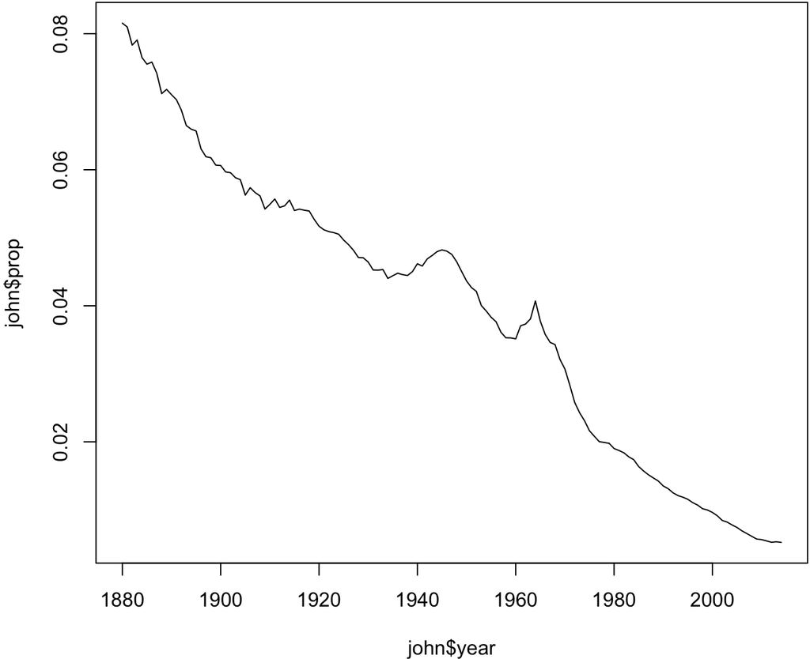

```r
> # Analyzing the name 'John'
> john <- babynames %>% filter(sex=="M", name=="John")
> plot(john$year, john$prop, type="l")
```

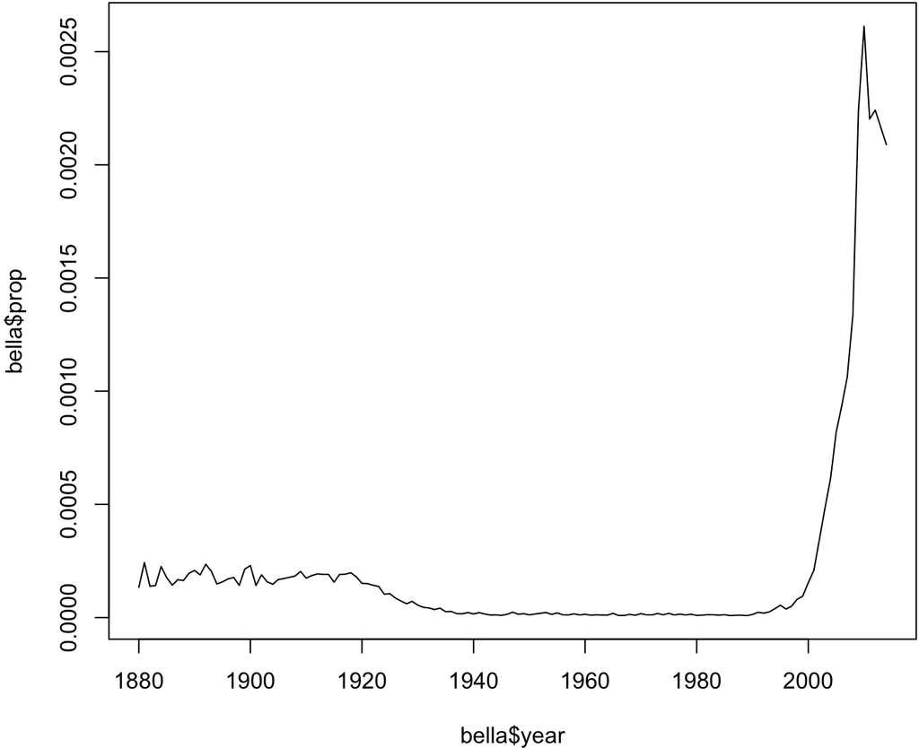

```r
> # Analyzing the name 'Bella'
> bella <- babynames %>% filter(sex=="F", name=="Bella")
> plot(bella$year, bella$prop, type="l")
```

# Additional Examples

You should study additional tutorials of `dplyr` that utilize other data sets:

- Read the `dplyr` [introductory vignette](https://cran.rstudio.com/web/packages/dplyr/vignettes/introduction.html)
- Read the examples given in *R Programming for Data Science*, the “Managing Data Frames with the `dplyr` Package” chapter

# Additional `dplyr` Features

- We’ve only scratched the surface – many interesting demos of `dplyr` can be found online
- `dplyr` can work with other data frame backends such as SQL databases
- There is an SQL interface for relational databases via the `DBI` package
- `dplyr` can be integrated with the `data.table` package for large fast tables
- There is a [healthy rivalry](http://stackoverflow.com/questions/21435339/data-table-vs-dplyr-can-one-do-something-well-the-other-cant-or-does-poorly) between `dplyr` and [`data.table`](https://cran.r-project.org/web/packages/data.table/index.html)

# Getting Data In and Out of R

# Some Functions for Data In/Out

- We have already used the `load()` function to load `.Rdata` files; the `save()` function saves R objects to `.RData` files
- The function `read.table()` is a standard function for reading in data from a **text** file
- Similarly `write.table()` is a standard function for writing data to a **text** file
- Study the help files:

```r
> ?read.table
> ?write.table
```

# Key Arguments

For `read.table`:

- `file` – the name of a file, or a connection
- `header` – logical indicating if the file has a header line
- `sep` – character string indicating how the values are separated
- `colClasses` – character vector indicating the class of each column
- `nrows` – maximum number of rows to be read in
- `skip` – number of lines to skip from beginning of file
- `stringsAsFactors` – a logical indicating if character strings should be coerced to factors

There are similar arguments for `write.table`.

# CSV Files

- A CSV file is a “comma separated value” file, meaning the entries are separated by commas
- The functions `read.csv()` and `write.csv()` are specialized versions of `read.table()` and `write.table()` where essentially it sets `sep=","`
- Many data sets are distributed as `.csv` files, so these are worth knowing about
- Read the help files, `?read.csv` and `?write.csv`

# `airquality` Data: Out

Let’s write the `airquality` data frame to a tab-delimited text file (aka TSV) and a CSV file.

```r
> data("airquality", package="datasets")
> head(airquality, n=8)
  Ozone Solar.R Wind Temp Month Day
1    41     190  7.4   67     5   1
2    36     118  8.0   72     5   2
3    12     149 12.6   74     5   3
4    18     313 11.5   62     5   4
5    NA      NA 14.3   56     5   5
6    28      NA 14.9   66     5   6
7    23     299  8.6   65     5   7
8    19      99 13.8   59     5   8
>
> write.table(airquality, file="../data/airquality.txt",
+             sep="\t", row.names=FALSE)
> write.csv(airquality, file="../data/airquality.csv",
+           row.names=FALSE)
```

# `airquality` Data: In

We will read in the two files we wrote in the previous slide. We first look at the top couple lines of each file using `readLines` to understand what is in the files.

```r
> readLines(con="../data/airquality.txt", n=2)
[1] "\"Ozone\"\t\"Solar.R\"\t\"Wind\"\t\"Temp\"\t\"Month\"\t\"Day\""
[2] "41\t190\t7.4\t67\t5\t1"
> aq1 <- read.table(file="../data/airquality.txt", header=TRUE,
+                   sep="\t")
>
> readLines(con="../data/airquality.csv", n=2)
[1] "\"Ozone\",\"Solar.R\",\"Wind\",\"Temp\",\"Month\",\"Day\""
[2] "41,190,7.4,67,5,1"
> aq2 <- read.csv(file="../data/airquality.csv", header=TRUE)
>
> dim(aq1) == dim(aq2)
[1] TRUE TRUE
> sum(aq1 != aq2, na.rm=TRUE)
[1] 0
```

# `readr` Package

There are a number of R packages that provide more sophisticated tools for getting data in and out of R, especially as data sets have become larger and larger.

One of those packages is `readr`. It reads and writes data quickly, provides a useful status bar for large files, and does a good job at determining data types.

`readr` is organized similarly to the base R functions. For example, there are functions `read_table`, `read_csv`, `write_tsv`, and `write_csv`.

# Scraping from the Web (Ex. 1)

There are several packages that facilitate “scraping” data from the web, including `rvest` demonstrated here.

```r
> library("rvest")
> schedule <- read_html("http://sml201.github.io/schedule/")
> first_table <- html_table(schedule)[[1]]
> names(first_table) <- c("week", "topics", "reading")
> first_table[4,"week"]
[1] 4
> first_table[4,"topics"] %>% strsplit(split="  ")
[[1]]
[1] "Getting data in and out of R"
[2] "Exploring and visualizing data (part 1)"
> first_table[4,"reading"] %>% strsplit(split="  ")
[[1]]
[1] "ADS Ch. 4"           " EDAR, Ch. 3–9"
[3] "EDAS, Ch. 5, 10, 11" "RPDS, Ch. 6, 7"
> grep("EDAR", first_table$reading)
[1]  3  4  5 11
```

# Scraping from the Web (Ex. 2)

The `rvest` documentation recommends [SelectorGadget](http://selectorgadget.com), which is “a javascript bookmarklet that allows you to interactively figure out what css selector you need to extract desired components from a page.”

```r
> usg_url <- "http://princetonusg.com/meet-your-usg-officers/"
> usg <- read_html(usg_url)
> officers <- html_nodes(usg, ".team-member-name") %>%
+             html_text
> head(officers, n=20)
 [1] "Ella Cheng"        "Aleksandra Czulak"
 [3] "Jeremy Burton"     "Hunter Dong"
 [5] "Sung Won Chang"    "Naimah Hakim"
 [7] "Jacob Cannon"      "Dallas Nan"
 [9] "Brandon McGhee"    "Christopher Hsu"
[11] "Ethan Marcus"      "Lavinia Liang"
[13] "Miranda Rosen"     "Shobhit Kumar"
[15] "Pooja Patel"       "Deana Davoudiasl"
[17] "Kristen Coke"      "Kishan Bhatt"
[19] "Cailin Hong"       "Paul Draper"
```

# APIs

API stands for “application programming interface” which is [a set of routines, protocols, and tools for building software and applications](https://en.wikipedia.org/wiki/Application_programming_interface).

A specific website may provide an API for scraping data from that website.

There are R packages that provide an interface with specific APIs, such as the [`twitteR`](https://cran.r-project.org/web/packages/twitteR/index.html) package.

# Exploratory Data Analysis

# What is EDA?

Exploratory data analysis (EDA) is the process of analzying data to uncover their key features.

John Tukey pioneered this framework, writing a seminal book on the topic (called *Exploratory Data Analysis*).

EDA involves calculating numerical summaries of data, visualizing data in a variety of ways, and considering interesting data points.

Before any model fitting is done to data, some exploratory data analysis should always be performed.

*Data science seems to focus much more on EDA than traditional statistics.*

# Possible Steps to EDA

*Exploratory Data Analysis with R* proposes some steps to EDA:

1. Formulate your question
2. Read in your data
3. Check the packaging
4. Run `str()`
5. Look at the top and the bottom of your data
6. Check your $n$’s (i.e., count things)
7. Validate with at least one external data source
8. Try the easy solution first
9. Challenge your solution
10. Follow up

However, EDA involves much more than these steps…

# Motor Trend Car Road Tests Data Set

# `mtcars` Data Set

Let’s use the Motor Trend Car Road Tests data set `mtcars` to establish some EDA techniques.

```r
> data("mtcars", package="datasets")
> head(mtcars)
                   mpg cyl disp  hp drat    wt  qsec vs am
Mazda RX4         21.0   6  160 110 3.90 2.620 16.46  0  1
Mazda RX4 Wag     21.0   6  160 110 3.90 2.875 17.02  0  1
Datsun 710        22.8   4  108  93 3.85 2.320 18.61  1  1
Hornet 4 Drive    21.4   6  258 110 3.08 3.215 19.44  1  0
Hornet Sportabout 18.7   8  360 175 3.15 3.440 17.02  0  0
Valiant           18.1   6  225 105 2.76 3.460 20.22  1  0
                  gear carb
Mazda RX4            4    4
Mazda RX4 Wag        4    4
Datsun 710           4    1
Hornet 4 Drive       3    1
Hornet Sportabout    3    2
Valiant              3    1
```

# Numerical Summaries of Data

# Useful Summaries

- **Center**: mean, median, mode
- **Quantiles**: percentiles, five number summaries
- **Spread**: standard deviation, variance, interquartile range
- **Outliers**

# Measures of Center

Suppose we have data points $x_1, x_2, \ldots, x_n$.

**Mean**:
$$\overline{x} = \frac{x_1 + x_2 + \cdots + x_n}{n}$$

**Median**: Order the points $x_{(1)} \leq x_{(2)} \leq \cdots \leq x_{(n)}$. The median is the middle value:  
- $x_{((n+1)/2)}$ if $n$ is odd  
- $(x_{(n/2)} + x_{(n/2+1)})/2$ if $n$ is even

**Mode**: The most frequently repeated value among the data (if any). If there are ties, then there is more than one mode.

# Mean, Median, and Mode in R

Let’s calculate these quantities in R.

```r
> mean(mtcars$mpg)
[1] 20.09062
> median(mtcars$mpg)
[1] 19.2
>
> sample_mode <- function(x) {
+   as.numeric(names(which(table(x) == max(table(x)))))
+ }
>
> sample_mode(round(mtcars$mpg))
[1] 15 21
```

It appears there is no R base function for calculating the mode.

# Quantiles and Percentiles

The $p$th **percentile** of $x_1, x_2, \ldots, x_n$ is a number such that $p$% of the data are less than this number.

The 25th, 50th, and 75th percentiles are called 1st, 2nd, and 3rd “quartiles”, respectively. These are sometimes denoted as Q1, Q2, and Q3. The median is the 50th percentile aka the 2nd quartile aka Q2.

In general, $q$-**quantiles** are cut points that divide the data into $q$ approximately equally sized groups. The cut points are the percentiles $1/q, 2/q, \ldots, (q-1)/q.$

# Five Number Summary

The “five number summary” is the minimum, the three quartiles, and the maximum. This can be calculated via `fivenum()` and `summary()`. [They can produce different values.](https://chemicalstatistician.wordpress.com/2013/08/12/exploratory-data-analysis-the-5-number-summary-two-different-methods-in-r-2/) Finally, `quantile()` extracts any set of percentiles.

```r
> fivenum(mtcars$mpg)
[1] 10.40 15.35 19.20 22.80 33.90
> summary(mtcars$mpg)
   Min. 1st Qu.  Median    Mean 3rd Qu.    Max.
  10.40   15.42   19.20   20.09   22.80   33.90
>
> quantile(mtcars$mpg, prob=seq(0, 1, 0.25))
    0%    25%    50%    75%   100%
10.400 15.425 19.200 22.800 33.900
```

# Measures of Spread

The variance, standard deviation (SD), and interquartile range (IQR) measure the “spread” of the data.

**Variance**:
$$s^2 = \frac{\sum_{i=1}^n \left(x_i - \overline{x}\right)^2}{n-1}$$

**Standard Deviation**: $s = \sqrt{s^2}$

**Iterquartile Range**: IQR $=$ Q3 $-$ Q1

The SD and IQR have the same units as the observed data, but the variance is in squared units.

# Variance, SD, and IQR in R

Variance:

```r
> var(mtcars$mpg)
[1] 36.3241
```

Standard deviation:

```r
> sd(mtcars$mpg)
[1] 6.026948
```

Interquartile range:

```r
> IQR(mtcars$mpg)
[1] 7.375
> diff(fivenum(mtcars$mpg)[c(2,4)])
[1] 7.45
```

# Identifying Outliers

An **outlier** is an unusual data point. Outliers can be perfectly valid but they can also be due to errors (as can non-outliers).

One must define what is meant by an outlier.

One definition is a data point that less than Q1 or greater than Q3 by 1.5 $\times$ IQR or more.

Another definition is a data point whose difference from the mean is greater than 3 $\times$ SD or more. For Normal distributed data (bell curve shaped), the probability of this is less than 0.27%.

# Application to `mtcars` Data

```r
> sd_units <- abs(mtcars$wt - mean(mtcars$wt))/sd(mtcars$wt)
> sum(sd_units > 3)
[1] 0
> max(sd_units)
[1] 2.255336
>
> iqr_outlier_cuts <- fivenum(mtcars$wt)[c(2,4)] +
+       c(-1.5, 1.5)*diff(fivenum(mtcars$wt)[c(2,4)])
> sum(mtcars$wt < iqr_outlier_cuts[1] |
+     mtcars$wt > iqr_outlier_cuts[2])
[1] 2
```

# Data Visualization Basics

# Plots

- Single variables:
  - Barplot
  - Boxplot
  - Histogram
  - Density plot
- Two or more variables:
  - Side-by-Side Boxplots
  - Stacked Barplot
  - Scatterplot

# R Base Graphics

- We’ll be plodding through “R base graphics” this week, which means graphics functions that come with R.
- By default they are very simple. However, they can be customized *a lot*, but it takes *a lot* of work.
- Also, the syntax varies significantly among plot types and some think the syntax is not user-friendly.
- We will consider a very highly used graphics package next week, called `ggplot2` that provides a “grammar of graphics”. It hits a sweet spot of “flexibility vs. complexity” for many data scientists.

# Read the Documentation

For all of the plotting functions covered below, read the help files.

```r
> ?barplot
> ?boxplot
> ?hist
> ?density
> ?plot
> ?legend
```

# Barplot

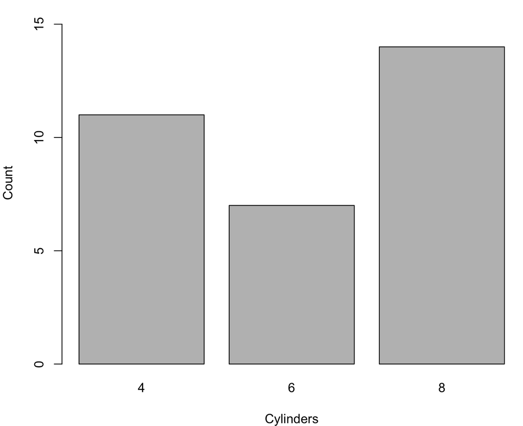

```r
> cyl_tbl <- table(mtcars$cyl)
> barplot(cyl_tbl, xlab="Cylinders", ylab="Count")
```

# Boxplot

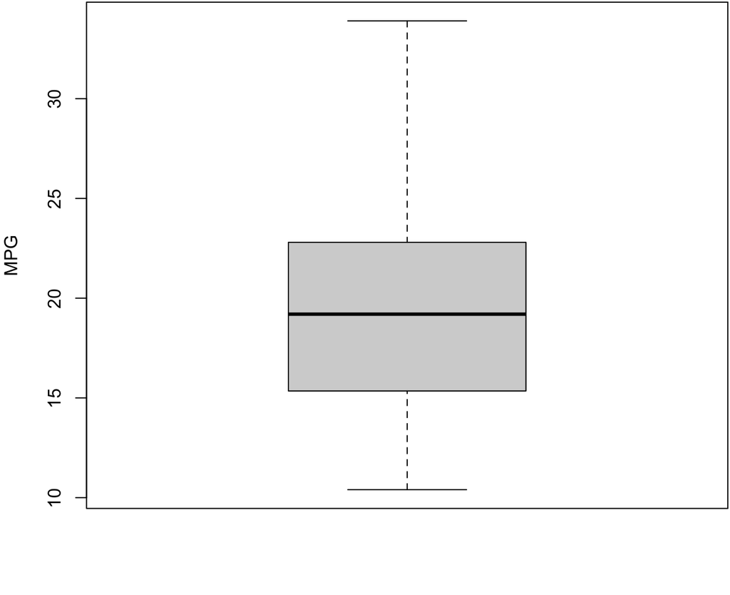

```r
> boxplot(mtcars$mpg, ylab="MPG", col="lightgray")
```

# Constructing Boxplots

- The top of the box is Q3
- The line through the middle of the box is the median
- The bottom of the box is Q1
- The top whisker is the minimum of Q3 + 1.5 $\times$ IQR or the largest data point
- The bottom whisker is the maximum of Q1 - 1.5 $\times$ IQR or the smallest data point
- Outliers lie outside of (Q1 - 1.5 $\times$ IQR) or (Q3 + 1.5 $\times$ IQR), and they are shown as points
- Outliers are calculated using the `fivenum()` function

# Boxplot with Outliers

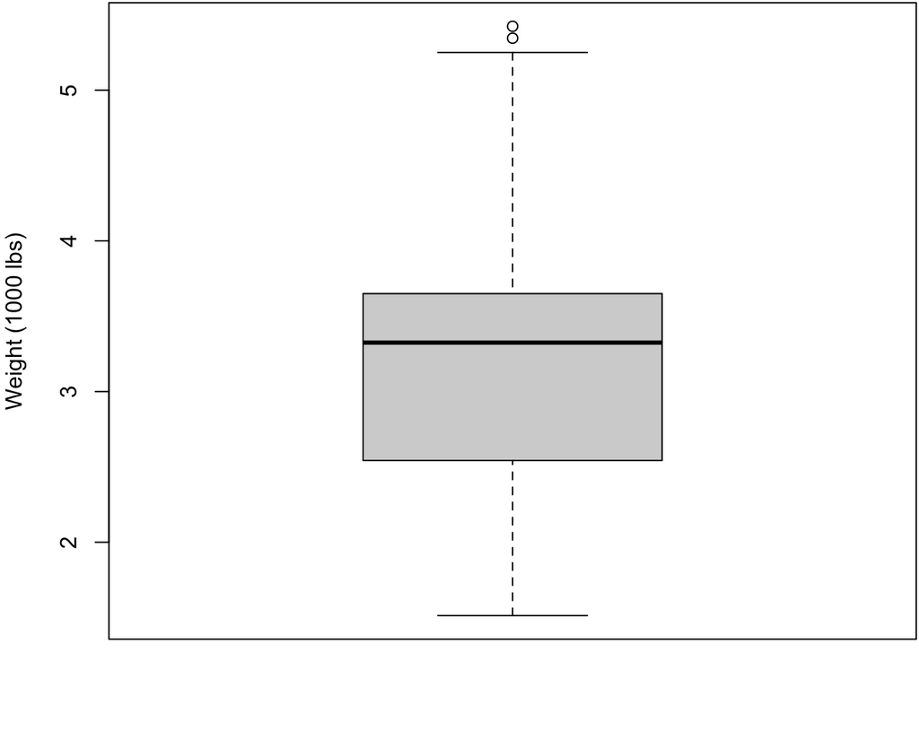

```r
> boxplot(mtcars$wt, ylab="Weight (1000 lbs)",
+         col="lightgray")
```

# Histogram

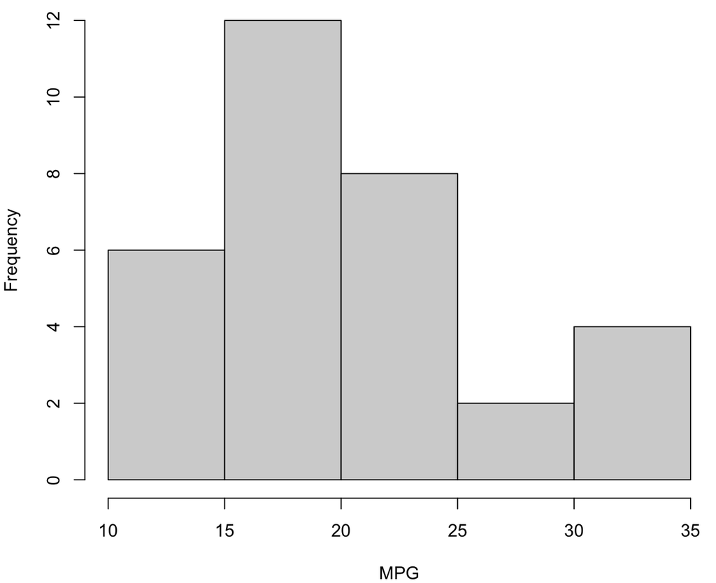

```r
> hist(mtcars$mpg, xlab="MPG", main="", col="lightgray")
```

# Histogram with More Breaks

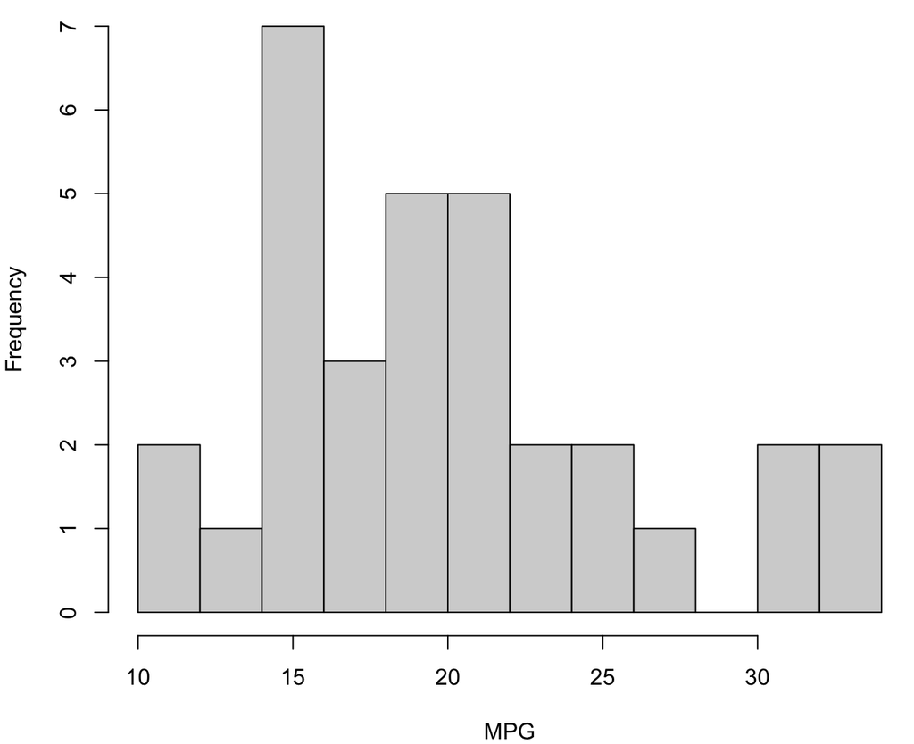

```r
> hist(mtcars$mpg, breaks=12, xlab="MPG", main="", col="lightgray")
```

# Density Plot

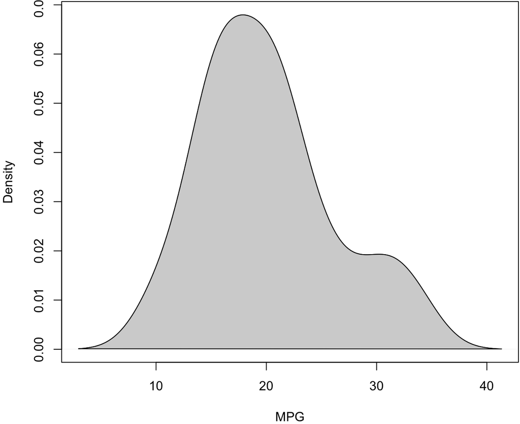

```r
> plot(density(mtcars$mpg), xlab="MPG", main="")
> polygon(density(mtcars$mpg), col="lightgray", border="black")
```

# Boxplot (Side-By-Side)

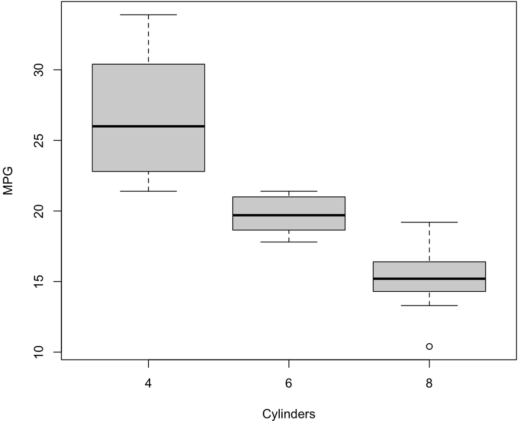

```r
> boxplot(mpg ~ cyl, data=mtcars, xlab="Cylinders",
+         ylab="MPG", col="lightgray")
```

# Stacked Barplot

```r
> counts <- table(mtcars$cyl, mtcars$gear)
> counts

     3  4  5
  4  1  8  2
  6  2  4  1
  8 12  0  2
```

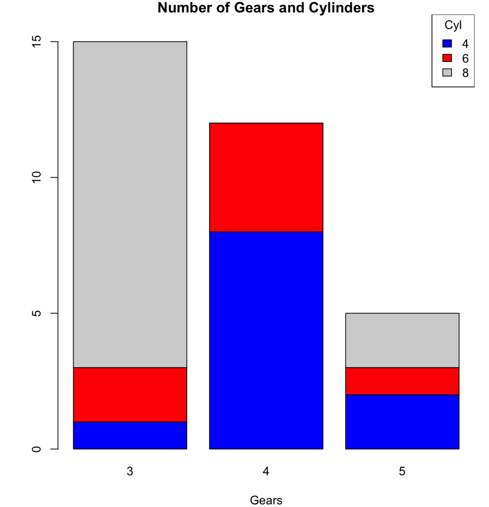

```r
> barplot(counts, main="Number of Gears and Cylinders",
+   xlab="Gears", col=c("blue","red", "lightgray"))
> legend(x="topright", title="Cyl",
+        legend = rownames(counts),
+        fill = c("blue","red", "lightgray"))
```

# Scatterplot

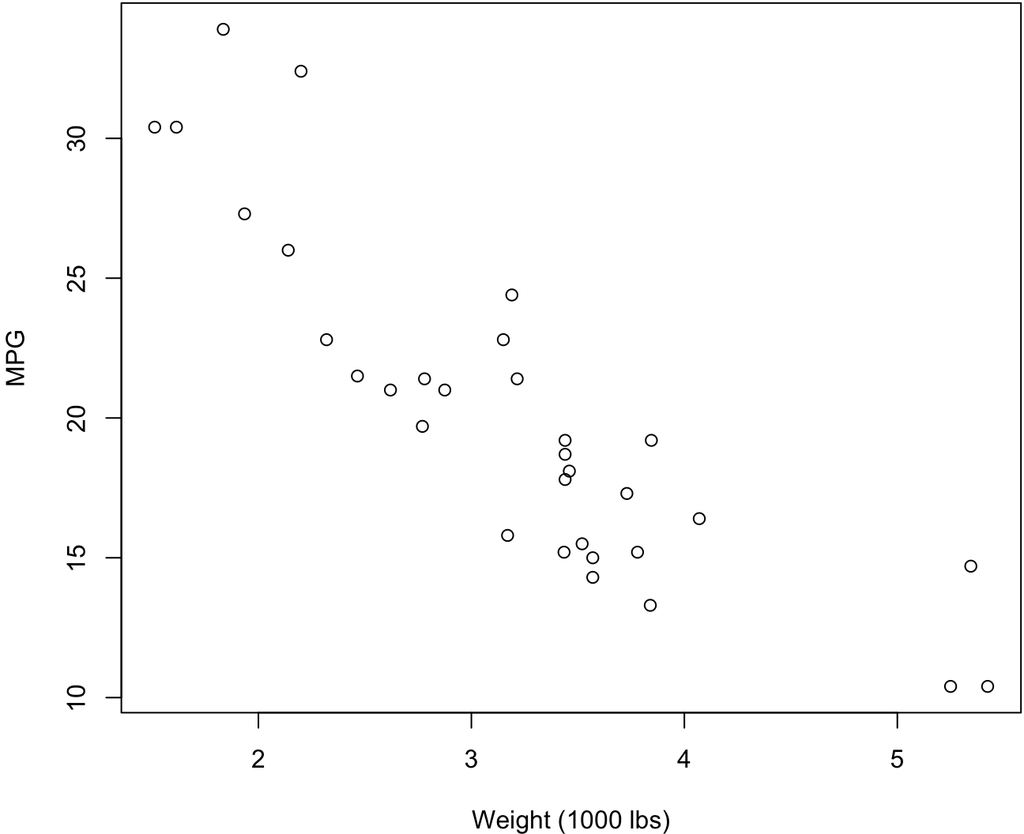

```r
> plot(mtcars$wt, mtcars$mpg, xlab="Weight (1000 lbs)",
+      ylab="MPG")
```

# Extras

# License

https://github.com/SML201/lectures/blob/master/LICENSE.md

# Source Code

https://github.com/SML201/lectures/tree/master/week4

# Session Information

```r
> sessionInfo()
R version 3.2.3 (2015-12-10)
Platform: x86_64-apple-darwin13.4.0 (64-bit)
Running under: OS X 10.11.3 (El Capitan)

locale:
[1] en_US.UTF-8/en_US.UTF-8/en_US.UTF-8/C/en_US.UTF-8/en_US.UTF-8

attached base packages:
[1] stats     graphics  grDevices utils     datasets  methods
[7] base

other attached packages:
[1] babynames_0.2.0 dplyr_0.4.3     rvest_0.3.1
[4] xml2_0.1.2      knitr_1.12.3    magrittr_1.5
[7] devtools_1.10.0

loaded via a namespace (and not attached):
 [1] Rcpp_0.12.3     R6_2.1.2        stringr_1.0.0
 [4] httr_1.1.0      highr_0.5.1     tools_3.2.3
 [7] revealjs_0.5.1  parallel_3.2.3  DBI_0.3.1
[10] selectr_0.2-3   htmltools_0.3   yaml_2.1.13
[13] lazyeval_0.1.10 digest_0.6.9    assertthat_0.1
[16] formatR_1.2.1   curl_0.9.6      memoise_1.0.0
[19] evaluate_0.8    rmarkdown_0.9.2 stringi_1.0-1
[22] XML_3.98-1.3
```